# Limma-voom Notebook

# limma

Limma methods are used to analysis microarry data.

## set-up

The DEA analysis is conducted using Limma-voom packege, using the data stored in package breastCancerVDX.

```r
# load packages
library(limma)
library(EnhancedVolcano)
library(edgeR)

# load the data
library(breastCancerVDX)
```

The `vdx` dataset from the breastCancerVDX package is an ExpressionSet of women diagnosed with breast cancer. It contains information about 22,000 genes and several variables including estrogen receptor (ER) status.

```r
data(vdx)
vdx
```

```
ExpressionSet (storageMode: lockedEnvironment)
assayData: 22283 features, 344 samples
  element names: exprs
protocolData: none
phenoData
  sampleNames: VDX_3 VDX_5 ... VDX_2038 (344 total)
  varLabels: samplename dataset ... e.os (21 total)
  varMetadata: labelDescription
featureData
  featureNames: 1007_s_at 1053_at ... AFFX-TrpnX-M_at (22283 total)
  fvarLabels: probe Gene.title ... GO.Component.1 (22 total)
  fvarMetadata: labelDescription
experimentData: use 'experimentData(object)'
  pubMedIds: 17420468
Annotation: hgu133a
```

## Design matrix

The factor er is the ER(oestrogen receptors) status, ER+ and ER-, where the code 0 means negative and 1 positive estrogen receptor.

```r
table(vdx$er)
```

```
  0   1
135 209
```

```r
#  define the comparison of interest (and the design of the experiment)
design <- model.matrix(~ vdx$er)
```

## DGE

Now we do a standard limma model fit

```r
# fitting the linear model
fit <- lmFit(vdx, design)

# using emprical bayes model to borrow strenth across genes with similar expression level
fit <- eBayes(fit)

# lists the top DEG
topTable(fit)
```

```
Removing intercept from test coefficients
```

|  | probe | Gene.title | Gene.symbol | Gene.ID | EntrezGene.ID | UniGene.title | UniGene.symbol | UniGene.ID | Nucleotide.Title | GI | GenBank.Accession | Platform_CLONEID | Platform_ORF | Platform_SPOTID | Chromosome.location | Chromosome.annotation | GO.Function | GO.Process | GO.Component | GO.Function.1 | GO.Process.1 | GO.Component.1 | logFC | AveExpr | t | P.Value | adj.P.Val | B |
| --- | --- | --- | --- | --- | --- | --- | --- | --- | --- | --- | --- | --- | --- | --- | --- | --- | --- | --- | --- | --- | --- | --- | --- | --- | --- | --- | --- | --- |
| 205225_at | 205225_at | estrogen receptor 1 | ESR1 | 2099 | 2099 | NA | NA | NA | Homo sapiens estrogen receptor 1 (ESR1), transcript variant 1, mRNA | 170295798 | NM_000125 | NA | NA | NA | 6q25.1 | Chromosome 6, NC_000006.11 (152011631..152424409) | estrogen receptor activity///estrogen response element binding///hormone binding///metal ion binding///nitric-oxide synthase regulator activity///protein binding///protein complex binding///sequence-s… | androgen metabolic process///antral ovarian follicle growth///epithelial cell development///epithelial cell proliferation involved in mammary gland duct elongation///estrogen receptor signaling pathwa… | T-tubule///chromatin remodeling complex///cytoplasm///membrane///neuron projection///nucleus///perikaryon///plasma membrane///terminal button | GO:0030284///GO:0034056///GO:0042562///GO:0046872///GO:0030235///GO:0005515///GO:0032403///GO:0043565///GO:0005496///GO:0003707///GO:0003700///GO:0008134///GO:0008270 | GO:0008209///GO:0001547///GO:0002064///GO:0060750///GO:0030520///GO:0008584///GO:0060749///GO:0060745///GO:0043526///GO:0002076///GO:0048146///GO:0048386///GO:0045885///GO:0060527///GO:0060523///GO:00… | GO:0030315///GO:0016585///GO:0005737///GO:0016020///GO:0043005///GO:0005634///GO:0043204///GO:0005886///GO:0043195 | 3.762901 | 11.377735 | 22.68392 | 2.001001e-70 | 4.458832e-66 | 149.19866 |
| 209603_at | 209603_at | GATA binding protein 3 | GATA3 | 2625 | 2625 | NA | NA | NA | wh43d10.x1 NCI_CGAP_Kid11 Homo sapiens cDNA clone IMAGE:2383507 3- similar to gb:X58072_rna1 TRANS-ACTING T-CELL SPECIFIC TRANSCRIPTION FACTOR (HUMAN);, mRNA sequence | 5361632 | AI796169 | NA | NA | NA | 10p15 | Chromosome 10, NC_000010.10 (8096667..8117164) | DNA binding///metal ion binding///sequence-specific DNA binding///transcription factor activity///transcription factor binding///zinc ion binding | anatomical structure morphogenesis///defense response///regulation of transcription, DNA-dependent///response to estrogen stimulus///transcription from RNA polymerase II promoter | nucleus | GO:0003677///GO:0046872///GO:0043565///GO:0003700///GO:0008134///GO:0008270 | GO:0009653///GO:0006952///GO:0006355///GO:0043627///GO:0006366 | GO:0005634 | 3.052348 | 9.941990 | 18.98154 | 1.486522e-55 | 1.656209e-51 | 115.46414 |
| 209604_s_at | 209604_s_at | GATA binding protein 3 | GATA3 | 2625 | 2625 | NA | NA | NA | Homo sapiens GATA binding protein 3, mRNA (cDNA clone MGC:2346 IMAGE:3504200), complete cds | 33871929 | BC003070 | NA | NA | NA | 10p15 | Chromosome 10, NC_000010.10 (8096667..8117164) | DNA binding///metal ion binding///sequence-specific DNA binding///transcription factor activity///transcription factor binding///zinc ion binding | anatomical structure morphogenesis///defense response///regulation of transcription, DNA-dependent///response to estrogen stimulus///transcription from RNA polymerase II promoter | nucleus | GO:0003677///GO:0046872///GO:0043565///GO:0003700///GO:0008134///GO:0008270 | GO:0009653///GO:0006952///GO:0006355///GO:0043627///GO:0006366 | GO:0005634 | 2.431309 | 13.185334 | 17.59968 | 5.839050e-50 | 4.337052e-46 | 102.75707 |
| 212956_at | 212956_at | TBC1 domain family, member 9 (with GRAM domain) | TBC1D9 | 23158 | 23158 | NA | NA | NA | qp61g12.x1 NCI_CGAP_Co8 Homo sapiens cDNA clone IMAGE:1927558 3-, mRNA sequence | 4085300 | AI348094 | NA | NA | NA | 4q31.21 | Chromosome 4, NC_000004.11 (141541936..141677471, complement) | GTPase activator activity///Rab GTPase activator activity///calcium ion binding | regulation of Rab GTPase activity | intracellular | GO:0005096///GO:0005097///GO:0005509 | GO:0032313 | GO:0005622 | 2.157435 | 11.702942 | 17.48711 | 1.665700e-49 | 9.279201e-46 | 101.72268 |
| 202088_at | 202088_at | solute carrier family 39 (zinc transporter), member 6 | SLC39A6 | 25800 | 25800 | NA | NA | NA | ts65a01.x1 NCI_CGAP_Kid8 Homo sapiens cDNA clone IMAGE:2233416 3-, mRNA sequence | 4686779 | AI635449 | NA | NA | NA | 18q12.2 | Chromosome 18, NC_000018.9 (33688494..33709357, complement) | metal ion transmembrane transporter activity | ion transport///transmembrane transport///zinc ion transport | endoplasmic reticulum///integral to membrane///plasma membrane | GO:0046873 | GO:0006811///GO:0055085///GO:0006829 | GO:0005783///GO:0016021///GO:0005886 | 1.719680 | 13.119496 | 17.30104 | 9.412084e-49 | 4.194589e-45 | 100.01376 |
| 212496_s_at | 212496_s_at | lysine (K)-specific demethylase 4B | KDM4B | 23030 | 23030 | NA | NA | NA | 601112063F1 NIH_MGC_16 Homo sapiens cDNA clone IMAGE:3352887 5-, mRNA sequence | 9127367 | BE256900 | NA | NA | NA | 19p13.3 | Chromosome 19, NC_000019.9 (4969124..5153609) | metal ion binding///nucleic acid binding///oxidoreductase activity///oxidoreductase activity, acting on single donors with incorporation of molecular oxygen, incorporation of two atoms of oxygen///pro… | chromatin modification///oxidation reduction///regulation of transcription | nucleus | GO:0046872///GO:0003676///GO:0016491///GO:0016702///GO:0005515///GO:0008270 | GO:0016568///GO:0055114///GO:0045449 | GO:0005634 | 1.459843 | 10.703942 | 16.85070 | 6.188671e-47 | 2.298369e-43 | 95.88265 |
| 215867_x_at | 215867_x_at | carbonic anhydrase XII | CA12 | 771 | 771 | NA | NA | NA | Homo sapiens mRNA; cDNA DKFZp564D066 (from clone DKFZp564D066) | 4884095 | AL050025 | NA | NA | NA | 15q22 | Chromosome 15, NC_000015.9 (63615730..63674075, complement) | carbonate dehydratase activity///lyase activity///metal ion binding///zinc ion binding | one-carbon metabolic process | integral to membrane///membrane | GO:0004089///GO:0016829///GO:0046872///GO:0008270 | GO:0006730 | GO:0016021///GO:0016020 | 2.246120 | 11.450485 | 16.79123 | 1.074845e-46 | 3.421537e-43 | 95.33780 |
| 209602_s_at | 209602_s_at | GATA binding protein 3 | GATA3 | 2625 | 2625 | NA | NA | NA | wh43d10.x1 NCI_CGAP_Kid11 Homo sapiens cDNA clone IMAGE:2383507 3- similar to gb:X58072_rna1 TRANS-ACTING T-CELL SPECIFIC TRANSCRIPTION FACTOR (HUMAN);, mRNA sequence | 5361632 | AI796169 | NA | NA | NA | 10p15 | Chromosome 10, NC_000010.10 (8096667..8117164) | DNA binding///metal ion binding///sequence-specific DNA binding///transcription factor activity///transcription factor binding///zinc ion binding | anatomical structure morphogenesis///defense response///regulation of transcription, DNA-dependent///response to estrogen stimulus///transcription from RNA polymerase II promoter | nucleus | GO:0003677///GO:0046872///GO:0043565///GO:0003700///GO:0008134///GO:0008270 | GO:0009653///GO:0006952///GO:0006355///GO:0043627///GO:0006366 | GO:0005634 | 2.921505 | 9.547850 | 16.43202 | 3.004184e-45 | 8.367780e-42 | 92.05058 |
| 212195_at | 212195_at | interleukin 6 signal transducer (gp130, oncostatin M receptor) | IL6ST | 3572 | 3572 | NA | NA | NA | Homo sapiens mRNA; cDNA DKFZp564F053 (from clone DKFZp564F053) | 4500013 | AL049265 | NA | NA | NA | 5q11 | Chromosome 5, NC_000005.9 (55236694..55290763, complement) | ciliary neurotrophic factor receptor activity///ciliary neurotrophic factor receptor binding///growth factor binding///contributes_to growth factor binding///interleukin-11 receptor activity///interle… | JAK-STAT cascade///ciliary neurotrophic factor-mediated signaling pathway///cytokine-mediated signaling pathway///glycogen metabolic process///interleukin-27-mediated signaling pathway///leukemia inhi… | ciliary neurotrophic factor receptor complex///external side of plasma membrane///extracellular region///extracellular space///integral to membrane///interleukin-6 receptor complex///oncostatin-M rece… | GO:0004897///GO:0005127///GO:0019838///contributes_to GO:0019838///GO:0004921///GO:0045509///contributes_to GO:0019981///contributes_to GO:0004915///contributes_to GO:0004915///contributes_to GO:00051… | GO:0007259///GO:0070120///GO:0019221///GO:0005977///GO:0070106///GO:0048861///GO:0070104///GO:0042102///GO:0002675///GO:0002821///GO:0045768///GO:0010613///GO:0008284///GO:0008284///GO:0045669///GO:00… | GO:0070110///GO:0009897///GO:0005576///GO:0005615///GO:0016021///GO:0005896///GO:0005900///GO:0005886 | 1.381778 | 11.737839 | 16.31864 | 8.581176e-45 | 2.124604e-41 | 91.01458 |
| 218195_at | 218195_at | chromosome 6 open reading frame 211 | C6orf211 | 79624 | 79624 | NA | NA | NA | Homo sapiens chromosome 6 open reading frame 211 (C6orf211), mRNA | 13375745 | NM_024573 | NA | NA | NA | 6q25.1 | Chromosome 6, NC_000006.11 (151773422..151791232) | protein binding | NA | NA | GO:0005515 | NA | NA | 1.738740 | 9.479901 | 16.27378 | 1.299472e-44 | 2.895613e-41 | 90.60496 |

logFC provides the information of log fold change, but we need to decide if this is 1-0 (ie. ER+ vs ER-) or the reverse

One method to do is check the reference level, which is the first level of the factor

```r
head(as.factor(vdx$er))
```

```
[1] 0 1 0 0 0 1
Levels: 0 1
```

The other method is calculate logFC by hand

```r
topTable(fit, n = 1)
```

```
Removing intercept from test coefficients
```

|  | probe | Gene.title | Gene.symbol | Gene.ID | EntrezGene.ID | UniGene.title | UniGene.symbol | UniGene.ID | Nucleotide.Title | GI | GenBank.Accession | Platform_CLONEID | Platform_ORF | Platform_SPOTID | Chromosome.location | Chromosome.annotation | GO.Function | GO.Process | GO.Component | GO.Function.1 | GO.Process.1 | GO.Component.1 | logFC | AveExpr | t | P.Value | adj.P.Val | B |
| --- | --- | --- | --- | --- | --- | --- | --- | --- | --- | --- | --- | --- | --- | --- | --- | --- | --- | --- | --- | --- | --- | --- | --- | --- | --- | --- | --- | --- |
| 205225_at | 205225_at | estrogen receptor 1 | ESR1 | 2099 | 2099 | NA | NA | NA | Homo sapiens estrogen receptor 1 (ESR1), transcript variant 1, mRNA | 170295798 | NM_000125 | NA | NA | NA | 6q25.1 | Chromosome 6, NC_000006.11 (152011631..152424409) | estrogen receptor activity///estrogen response element binding///hormone binding///metal ion binding///nitric-oxide synthase regulator activity///protein binding///protein complex binding///sequence-s… | androgen metabolic process///antral ovarian follicle growth///epithelial cell development///epithelial cell proliferation involved in mammary gland duct elongation///estrogen receptor signaling pathwa… | T-tubule///chromatin remodeling complex///cytoplasm///membrane///neuron projection///nucleus///perikaryon///plasma membrane///terminal button | GO:0030284///GO:0034056///GO:0042562///GO:0046872///GO:0030235///GO:0005515///GO:0032403///GO:0043565///GO:0005496///GO:0003707///GO:0003700///GO:0008134///GO:0008270 | GO:0008209///GO:0001547///GO:0002064///GO:0060750///GO:0030520///GO:0008584///GO:0060749///GO:0060745///GO:0043526///GO:0002076///GO:0048146///GO:0048386///GO:0045885///GO:0060527///GO:0060523///GO:00… | GO:0030315///GO:0016585///GO:0005737///GO:0016020///GO:0043005///GO:0005634///GO:0043204///GO:0005886///GO:0043195 | 3.762901 | 11.37774 | 22.68392 | 2.001001e-70 | 4.458832e-66 | 149.1987 |

```r
genename <- rownames(topTable(fit, n=1))
```

```
Removing intercept from test coefficients
```

```r
typeMean <- tapply(exprs(vdx)[genename,], vdx$er, mean)
typeMean["1"] - typeMean["0"]
```

```
       1
3.762901
```

This confirms the results.

other important parameters: - t: the t-statistic used to assess differential expression. - P.Value: the p-value for differential expression; this value is not adjusted for multiple testing. - adj.P.Val: the p-value adjusted for multiple testing. Different adjustment methods are available, the default is Benjamini-Horchberg.

## plots

Volcano plot can be use to visualize the genes that are differentially expressed at a given fold-change and p-value.

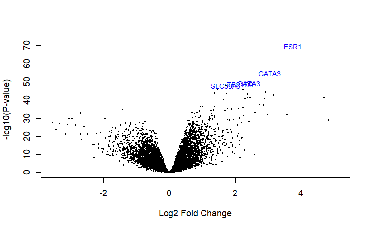

```r
volcanoplot(fit, coef=2, names = fit$genes$Gene.symbol,
            highlight = 5)
```

The graph will lookes better using package `EnhancedVolcano`

```r
toptable <- topTable(fit, n = Inf)
```

```
Removing intercept from test coefficients
```

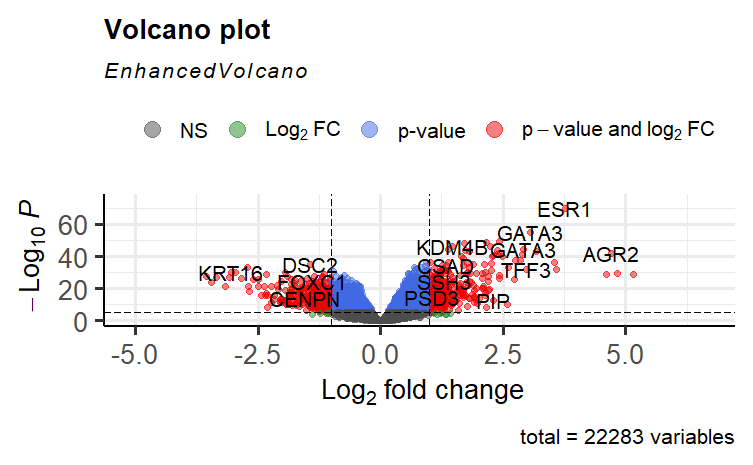

```r
EnhancedVolcano(toptable,
    lab = toptable$Gene.symbol,
    x = 'logFC',
    y = 'P.Value')
```

Another state-of-the-art plot is MA-plot. It is used to check whether data are comparable among groups (i.e. normalization worked properly). This can be created using a function available in limma.

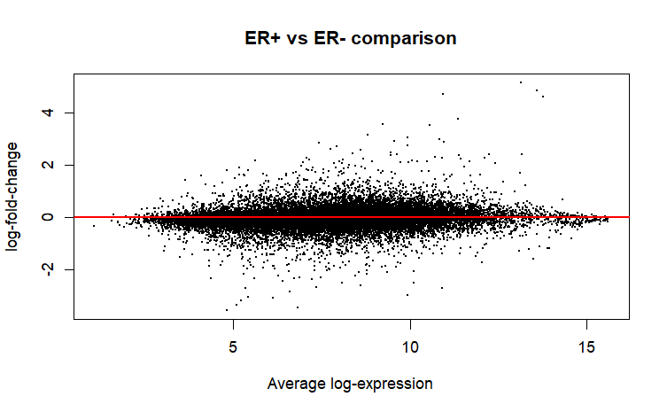

```r
limma::plotMA(fit, coef=2, main="ER+ vs ER- comparison")
abline(h=0, col="red", lwd=2)
```

# limma-voom

## set-up

```r
# load the data
counts <- read.delim("all_counts.txt", row.names = 1)
head(counts)
```

|  | C61 | C62 | C63 | C64 | C91 | C92 | C93 | C94 | I561 | I562 | I563 | I564 | I591 | I592 | I593 | I594 | I861 | I862 | I863 | I864 | I891 | I892 | I893 | I894 |
| --- | --- | --- | --- | --- | --- | --- | --- | --- | --- | --- | --- | --- | --- | --- | --- | --- | --- | --- | --- | --- | --- | --- | --- | --- |
| AT1G01010 | 289 | 317 | 225 | 343 | 325 | 449 | 310 | 299 | 563 | 438 | 380 | 407 | 678 | 386 | 567 | 421 | 130 | 411 | 382 | 190 | 501 | 390 | 480 | 407 |
| AT1G01020 | 127 | 78 | 142 | 130 | 156 | 146 | 144 | 95 | 138 | 129 | 99 | 118 | 154 | 140 | 127 | 154 | 35 | 132 | 97 | 46 | 139 | 175 | 137 | 123 |
| AT1G03987 | 0 | 0 | 0 | 0 | 0 | 0 | 0 | 0 | 0 | 0 | 0 | 0 | 0 | 0 | 0 | 0 | 0 | 0 | 0 | 0 | 0 | 0 | 0 | 0 |
| AT1G01030 | 17 | 25 | 32 | 24 | 22 | 25 | 21 | 35 | 18 | 6 | 46 | 33 | 19 | 8 | 14 | 21 | 37 | 16 | 19 | 38 | 24 | 18 | 37 | 23 |
| AT1G01040 | 605 | 415 | 506 | 565 | 762 | 854 | 658 | 753 | 704 | 692 | 641 | 601 | 704 | 508 | 733 | 614 | 297 | 521 | 542 | 381 | 651 | 573 | 650 | 550 |
| AT1G03993 | 1 | 1 | 0 | 0 | 0 | 0 | 1 | 1 | 3 | 0 | 1 | 1 | 1 | 0 | 0 | 0 | 0 | 1 | 0 | 1 | 3 | 1 | 1 | 1 |

## proprocessing of the data

```r
dge <- DGEList(counts)
```

### filtering

removing genes with low counts data because: - From a biological point of view, genes that not expressed at a biologically meaningful level in any condition are not of interest and are therefore best ignored. - From a statistical point of view, removing low count genes allows the mean-variance relationship in the data to be estimated with greater reliability and also reduces the number of statistical tests that need to be carried out in downstream analyses looking at differential expression.

```r
keep.exprs <- filterByExpr(dge)
dge.filt <- dge[keep.exprs,]
dim(dge.filt)
```

```
[1] 18509    24
```

### normalization

```r
# the normalization is finished by TMM in edgeR
dge <- calcNormFactors(dge)
```

### design matrix

Our experiment has two factors, cultivar (“C”, “I5”, or “I8”) and time (6 or 9)

```r
snames <- colnames(counts) # Sample names
snames
```

```
 [1] "C61"  "C62"  "C63"  "C64"  "C91"  "C92"  "C93"  "C94"  "I561" "I562"
[11] "I563" "I564" "I591" "I592" "I593" "I594" "I861" "I862" "I863" "I864"
[21] "I891" "I892" "I893" "I894"
```

```r
cultivar <- substr(snames, 1, nchar(snames) - 2)
time <- substr(snames, nchar(snames) - 1, nchar(snames) - 1)
cultivar
```

```
 [1] "C"  "C"  "C"  "C"  "C"  "C"  "C"  "C"  "I5" "I5" "I5" "I5" "I5" "I5" "I5"
[16] "I5" "I8" "I8" "I8" "I8" "I8" "I8" "I8" "I8"
```

```r
group <- interaction(cultivar, time)
group
```

```
 [1] C.6  C.6  C.6  C.6  C.9  C.9  C.9  C.9  I5.6 I5.6 I5.6 I5.6 I5.9 I5.9 I5.9
[16] I5.9 I8.6 I8.6 I8.6 I8.6 I8.9 I8.9 I8.9 I8.9
Levels: C.6 I5.6 I8.6 C.9 I5.9 I8.9
```

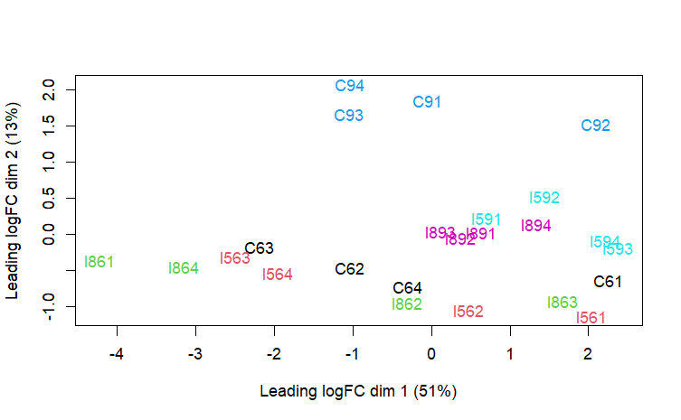

```r
plotMDS(dge, col = as.numeric(group))
```

## voom transformation

Because the varieties included in experimental sequencing, it is common practice to transform raw counts onto a scale that accounts for such library size differences. Popular transformations include counts per million (CPM), log2-counts per million (log-CPM), reads per kilobase of transcript per million (RPKM), and fragments per kilobase of transcript per million (FPKM). Here raw counts are converted log-CPM values using the voom function in limma package.

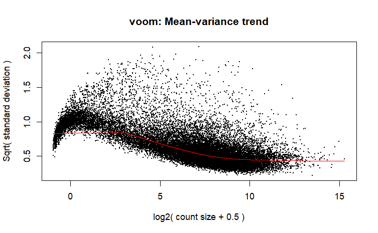

```r
mm <- model.matrix( ~ group)
v <- voom(dge, design = mm, plot = TRUE)
```

```r
cutoff <- 1
drop <- which(apply(cpm(dge), 1, max) < cutoff)
dge <- dge[-drop,]
dim(dge) # number of genes left
```

```
[1] 21080    24
```

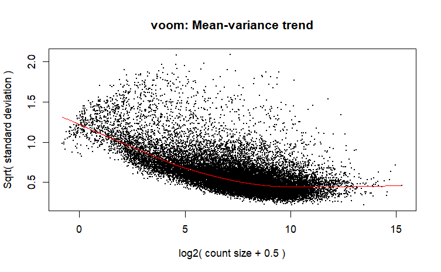

```r
mm <- model.matrix( ~ group)
v <- voom(dge, design = mm, plot = TRUE)
```

This fitted smoothed curve (red line) is used to obtain weights for each gene and sample that are passed into limma along with the log2 CPMs.

## limma to identify the DEGs

```r
fit <- lmFit(v, mm)
```

### single factor

Specify which groups to compare:

```r
contr <- makeContrasts(groupI5.9 - groupI5.6, levels = colnames(coef(fit)))
contr
```

```
           Contrasts
Levels      groupI5.9 - groupI5.6
  Intercept                     0
  groupI5.6                    -1
  groupI8.6                     0
  groupC.9                      0
  groupI5.9                     1
  groupI8.9                     0
```

```r
tmp <- contrasts.fit(fit, contr)
tmp <- eBayes(fit)
top.table <- topTable(tmp, sort.by = "none", n = Inf)
```

```
Removing intercept from test coefficients
```

```r
head(top.table, 20)
```

|  | groupI5.6 | groupI8.6 | groupC.9 | groupI5.9 | groupI8.9 | AveExpr | F | P.Value | adj.P.Val |
| --- | --- | --- | --- | --- | --- | --- | --- | --- | --- |
| AT1G01010 | 0.53644370 | 0.2279446 | 0.20580445 | 0.68659086 | 0.526399516 | 5.19567420 | 4.5360622 | 5.963617e-03 | 0.0197413692 |
| AT1G01020 | -0.03152318 | -0.3180096 | 0.15875297 | 0.19012695 | 0.205427876 | 3.55281779 | 2.5745942 | 5.792823e-02 | 0.1088251593 |
| AT1G01030 | -0.32143420 | 0.3084243 | 0.03477863 | -0.76764670 | -0.035226202 | 1.16826193 | 0.8609585 | 5.234567e-01 | 0.5955563083 |
| AT1G01040 | 0.27097286 | 0.1028739 | 0.50635951 | 0.18809577 | 0.139482729 | 5.87943361 | 5.4120996 | 2.439554e-03 | 0.0104071742 |
| AT1G01050 | -0.09734846 | -0.1347759 | 0.02052702 | 0.15457707 | 0.113060739 | 6.60603174 | 2.2830032 | 8.390879e-02 | 0.1448883686 |
| AT1G01060 | -0.34550979 | -0.4172467 | 1.15805850 | 0.46265062 | 0.568141280 | 8.04631370 | 19.3007553 | 3.662849e-07 | 0.0000297349 |
| AT1G01070 | 0.13818775 | -0.2392617 | -0.93776528 | 0.08864211 | -0.392112574 | 4.44829932 | 8.5593336 | 1.601030e-04 | 0.0016111468 |
| AT1G01080 | 0.21844692 | 0.7224870 | -0.46403938 | -0.31417528 | -0.350984388 | 2.98115914 | 2.1420698 | 1.006122e-01 | 0.1668296752 |
| AT1G01090 | 0.10984261 | 0.1696551 | -0.32112922 | -0.06538088 | -0.014300008 | 7.97772826 | 4.9552453 | 3.854763e-03 | 0.0144049657 |
| AT1G01100 | -0.21941942 | -0.1058441 | -0.09332221 | 0.25828790 | 0.229691942 | 8.00358302 | 2.5634316 | 5.874766e-02 | 0.1100115992 |

[output cut: 10 more lines]

```r
length(which(top.table$adj.P.Val < 0.05))
```

```
[1] 8646
```

# source

- https://rpubs.com/jrgonzalezISGlobal/transcriptomic_analyses
- https://kasperdanielhansen.github.io/genbioconductor/html/limma.html

```r
#Create new model matrix:

mm <- model.matrix(~cultivar*time)
#We are specifying that model includes effects for cultivar, time, and the cultivar-time interaction (which allows the differences between cultivars to differ across time)

colnames(mm)
```

```
[1] "(Intercept)"      "cultivarI5"       "cultivarI8"       "time9"
[5] "cultivarI5:time9" "cultivarI8:time9"
```

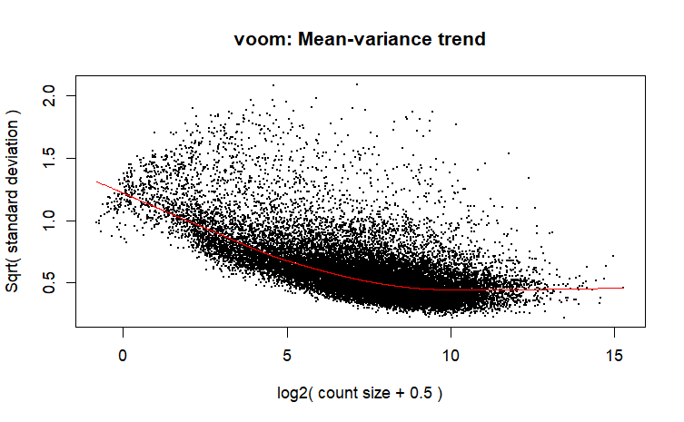

```r
y <- voom(dge, mm, plot = T)
```

```r
fit <- lmFit(y, mm)
head(coef(fit))
```

```
          (Intercept)  cultivarI5 cultivarI8      time9 cultivarI5:time9
AT1G01010    4.837410  0.53644370  0.2279446 0.20580445      -0.05565729
AT1G01020    3.530869 -0.03152318 -0.3180096 0.15875297       0.06289715
AT1G01030    1.250817 -0.32143420  0.3084243 0.03477863      -0.48099113
AT1G01040    5.676015  0.27097286  0.1028739 0.50635951      -0.58923660
AT1G01050    6.598712 -0.09734846 -0.1347759 0.02052702       0.23139851
AT1G01060    7.807988 -0.34550979 -0.4172467 1.15805850      -0.34989810
          cultivarI8:time9
AT1G01010       0.09265044
AT1G01020       0.36468449
AT1G01030      -0.37842909
AT1G01040      -0.46975071
AT1G01050       0.22730960
AT1G01060      -0.17267051
```

# resource

- https://ucdavis-bioinformatics-training.github.io/2018-June-RNA-Seq-Workshop/thursday/DE.html
- https://rpubs.com/jrgonzalezISGlobal/transcriptomic_analyses